# Assignment 2

## Submit as an HTML file

Print your ID below (do not input your name)

```python
print("2579381")
```

```
2579381
```

(a) Import the pandas and matplotlib packages

```python
import pandas as pd
import matplotlib.pyplot as plt
```

(b) Open the dataset "athletes.csv" in the "data" folder

- Read it as a pandas object called "athlete"
- Note: This is a dataset of all Olympic Athletes from 1896 to 2022

```python
athlete = pd.read_csv('data/athletes.csv')
```

(c) View the dataset and create a list of variable names

```python
# Create a list, e.g. "variable_names = [ "name1", "name2", "name3" ]"
# Manually type the names of the first 4 variables (not including ID)
# If you're viewing the dataset from the VS-Code "Variables" tool, you'll see an extra column "index". Do not include this in your list.

variable_names = ["Name","Sex","Age","Height"]
```

(d) Compute descriptive statistics for the third variable in the dataset

- One way to do this is:

athlete["Age"].describe()

- Do something similar, but with the list you created above.
- Substitute "Age" with a command that automatically extracts the third element in the list

```python
# Remember that the numbering in Python starts at zero
# For example:
# list_colors = ["red","green","yellow"]
# list_colors[1] will output "green"

athlete[variable_names[2]].describe()
```

```
count    261644.000000
mean         25.556879
std           6.393543
min          10.000000
25%          21.000000
50%          24.000000
75%          28.000000
max          97.000000
Name: Age, dtype: float64
```

(e) Show a scatter plot that shows "Height" in the x-axis and "Weight" in the y-axis.

- Label the axes for full points
- Note: This question does not depend on (d)
- Give a one sentence interpretation of the plot

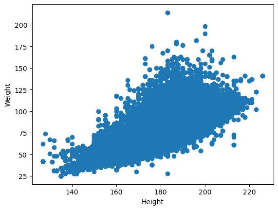

```python
plt.scatter(x =athlete.Height, y=athlete.Weight)
plt.xlabel("Height")
plt.ylabel("Weight")
plt.show()
```

This scatter plot describes the relationship between Height and Weight for all olympic athletes from 1896 to 2022. In general, for olympic athletes, as Height increases so does Weight.